# Analysis of Military Spending

### DATS 6103-O11- Introduction to Data Mining

# Purpose of Project

The purpose of this project is to compare the overall military spending in light of their GDP. Specifically, I will be analyzing the military spending of the following countries: United States, China, Russia, Germany, United Kingdom, France, Italy, Iran, Israel, Saudi Arabia.

This project will utizilze data from the years 2010, 2012, 2014, 2016, and 2019. I chose to use a variety of years from the last 10 years in order to see how countries have much been spending on the military over a larger span of time. Utiziling widely set available data will help me clearly see how much each nation will continue spending in coming years.

The data set I used for this project came from the Sipri. All of the data I found was freely avaiable to download. I used the Sipri Military Expenditure Database. This database observes data up to 2019. All of the data I found was freely avaiable to download. https://www.sipri.org/databases/milex

# Part 1 - Using Data

In this section, I will be importing, cleaning up, and displaying the dataframes that I will be using throughout the rest of this project.

## 1.1 - Importing Data

```python
import pandas as pd
import matplotlib.pyplot as plt
from IPython.display import display
```

```python
# Setting options for the display over this entire project

pd.set_option('display.notebook_repr_html', True)# When True, IPython notebook will use html representation for pandas
pd.set_option('display.precision', 2) # Floating point output precision of 2
pd.set_option("display.float.format", lambda x: "%.2f" % x) #Changing decimal
```

```python
xls = pd.ExcelFile('Military_spending.xlsx')
USD = xls.parse('Current USD') # Reading the Excel workbook into working dataframe
USD = pd.read_excel(xls, 'Current USD', skiprows=5, index_col=0)
USD.replace(("xxx",". ."), "N/A", inplace=True) # replacing
USD.fillna("N/A", inplace=True) # inputting new replacement in DF
USD.head()
```

| Country | Notes | 1949 | 1950 | 1951 | 1952 | 1953 | 1954 | 1955 | 1956 | 1957 | ... | 2010 | 2011 | 2012 | 2013 | 2014 | 2015 | 2016 | 2017 | 2018 | 2019 |
| --- | --- | --- | --- | --- | --- | --- | --- | --- | --- | --- | --- | --- | --- | --- | --- | --- | --- | --- | --- | --- | --- |
| Africa | N/A | N/A | N/A | N/A | N/A | N/A | N/A | N/A | N/A | N/A | ... | N/A | N/A | N/A | N/A | N/A | N/A | N/A | N/A | N/A | N/A |
| North Africa | N/A | N/A | N/A | N/A | N/A | N/A | N/A | N/A | N/A | N/A | ... | N/A | N/A | N/A | N/A | N/A | N/A | N/A | N/A | N/A | N/A |
| Algeria | 1 | N/A | N/A | N/A | N/A | N/A | N/A | N/A | N/A | N/A | ... | 5671.31 | 8652.24 | 9326.29 | 10161.59 | 9724.38 | 10412.71 | 10217.08 | 10073.36 | 9583.72 | 10303.60 |
| Libya | ‡ ¶ 2 | N/A | N/A | N/A | N/A | N/A | N/A | N/A | N/A | N/A | ... | N/A | N/A | 2987.41 | 3964.69 | 3755.66 | N/A | N/A | N/A | N/A | N/A |
| Morocco | 3 | N/A | N/A | N/A | N/A | N/A | N/A | N/A | 23.71 | 35.40 | ... | 3160.80 | 3342.70 | 3402.70 | 4065.55 | 4048.61 | 3268.36 | 3327.03 | 3461.46 | 3696.86 | 3721.32 |

5 rows × 72 columns

```python
xls = pd.ExcelFile('Military_spending.xlsx')
shareGDP = xls.parse('Share of GDP')
shareGDP = pd.read_excel(xls, 'Share of GDP', skiprows=5, index_col=0)
shareGDP.replace(("xxx",". ."), "N/A", inplace=True)
shareGDP.fillna("N/A", inplace=True)
shareGDP.head()
```

| Country | Notes | 1949 | 1950 | 1951 | 1952 | 1953 | 1954 | 1955 | 1956 | 1957 | ... | 2010 | 2011 | 2012 | 2013 | 2014 | 2015 | 2016 | 2017 | 2018 | 2019 |
| --- | --- | --- | --- | --- | --- | --- | --- | --- | --- | --- | --- | --- | --- | --- | --- | --- | --- | --- | --- | --- | --- |
| Africa | N/A | N/A | N/A | N/A | N/A | N/A | N/A | N/A | N/A | N/A | ... | N/A | N/A | N/A | N/A | N/A | N/A | N/A | N/A | N/A | N/A |
| North Africa | N/A | N/A | N/A | N/A | N/A | N/A | N/A | N/A | N/A | N/A | ... | N/A | N/A | N/A | N/A | N/A | N/A | N/A | N/A | N/A | N/A |
| Algeria | 1 | N/A | N/A | N/A | N/A | N/A | N/A | N/A | N/A | N/A | ... | 0.04 | 0.04 | 0.04 | 0.05 | 0.06 | 0.06 | 0.06 | 0.06 | 0.06 | 0.06 |
| Libya | ‡ ¶ 2 | N/A | N/A | N/A | N/A | N/A | N/A | N/A | N/A | N/A | ... | N/A | N/A | 0.04 | 0.08 | 0.15 | N/A | N/A | N/A | N/A | N/A |
| Morocco | 3 | N/A | N/A | N/A | N/A | N/A | N/A | N/A | 0.01 | 0.02 | ... | 0.03 | 0.03 | 0.03 | 0.04 | 0.04 | 0.03 | 0.03 | 0.03 | 0.03 | 0.03 |

5 rows × 72 columns

```python
xls = pd.ExcelFile('Military_spending.xlsx')
pop = xls.parse('Per capita')
pop = pd.read_excel(xls, 'Per capita', skiprows=6, index_col=0)
pop.replace(("xxx",". ."), "N/A", inplace=True)
pop.fillna("N/A", inplace=True)
pop.head()
```

| Country | Notes | 1988 | 1989 | 1990 | 1991 | 1992 | 1993 | 1994 | 1995 | 1996 | ... | 2010 | 2011 | 2012 | 2013 | 2014 | 2015 | 2016 | 2017 | 2018 | 2019 |
| --- | --- | --- | --- | --- | --- | --- | --- | --- | --- | --- | --- | --- | --- | --- | --- | --- | --- | --- | --- | --- | --- |
| Africa | N/A | N/A | N/A | N/A | N/A | N/A | N/A | N/A | N/A | N/A | ... | N/A | N/A | N/A | N/A | N/A | N/A | N/A | N/A | N/A | N/A |
| North Africa | N/A | N/A | N/A | N/A | N/A | N/A | N/A | N/A | N/A | N/A | ... | N/A | N/A | N/A | N/A | N/A | N/A | N/A | N/A | N/A | N/A |
| Algeria | 1 | 42.08 | 34.03 | 35.11 | 21.40 | 38.97 | 46.21 | 47.31 | 42.93 | 49.63 | ... | 157.64 | 236.00 | 249.47 | 266.43 | 249.83 | 262.10 | 251.95 | 243.38 | 226.95 | 239.32 |
| Libya | ‡ ¶ 2 | N/A | N/A | N/A | N/A | N/A | N/A | N/A | N/A | N/A | ... | N/A | N/A | 475.27 | 627.29 | 590.32 | N/A | N/A | N/A | N/A | N/A |
| Morocco | 3 | 38.37 | 40.67 | 43.12 | 45.46 | 47.78 | 47.86 | 51.36 | 53.27 | 52.85 | ... | 97.73 | 101.97 | 102.36 | 120.58 | 118.41 | 94.29 | 94.72 | 97.28 | 102.61 | 102.03 |

5 rows × 33 columns

## 1.2 - Filter out data by country and year

I am looking for the 10 following countries: United States, China, Russia, Germany, UK, France, Italy, Iran, Israel, Saudi Arabia for the years of 2010, 2012, 2014, 2016, and 2019.

First, I decided to define a function to show my selected data. I defined my rows by country and my columns by year. Then, I applied my function to the three datasets that I extracted: current USD, share of GDP, and per capita. When I called for each of my datasets, I sorted each set alphabetically by country.

```python
# Define a function to set my selected dataframes
def select(xls):
    rname = ['USA', 'China', 'Russia', 'Germany',  # my rows
             'UK', 'France', 'Italy', 'Iran',
             'Israel', 'Saudi Arabia']
    cname = [2010, 2012, 2014, 2016, 2019] # my columns

    xls = xls.loc[rname, cname] #setting the bast of my dataframe to read the countries as rows and years as columns
    return xls
```

```python
# Combined dataframe that shows the military spending in US Dollars of my 10 countries listed out by year

USD = select(USD).sort_values("Country")
USD
```

| Country | 2010 | 2012 | 2014 | 2016 | 2019 |
| --- | --- | --- | --- | --- | --- |
| China | 115711.78 | 157390.38 | 200772.20 | 216404.28 | 261081.94 |
| France | 52044.06 | 50216.51 | 53134.75 | 47370.59 | 50118.93 |
| Germany | 44852.96 | 44470.34 | 44216.06 | 39724.91 | 49276.76 |
| Iran | 13561.27 | 16493.96 | 9901.11 | 12263.96 | 12623.16 |
| Israel | 13875.21 | 14600.67 | 17810.04 | 17488.18 | 20464.93 |
| Italy | 32020.82 | 29781.01 | 27701.03 | 25033.03 | 26790.44 |
| Russia | 58720.23 | 81469.40 | 84696.50 | 69245.31 | 65102.57 |
| Saudi Arabia | 45244.53 | 56497.87 | 80762.40 | 63672.80 | 61866.67 |
| UK | 58082.85 | 58495.66 | 59182.86 | 48118.94 | 48650.38 |
| USA | 738005 | 725205 | 647789 | 639856.44 | 731751.40 |

```python
USD.dtypes
```

```
2010    object
2012    object
2014    object
2016    object
2019    object
dtype: object
```

```python
# Combined dataframe that shows the share of GDP of the 10 countries listed out by year

shareGDP = select(shareGDP).sort_values("Country")

# This is to change the values to a percent value
percentShareGDP = shareGDP * 100
percentShareGDP
```

| Country | 2010 | 2012 | 2014 | 2016 | 2019 |
| --- | --- | --- | --- | --- | --- |
| China | 1.91 | 1.84 | 1.91 | 1.93 | 1.89 |
| France | 1.97 | 1.87 | 1.86 | 1.92 | 1.86 |
| Germany | 1.32 | 1.26 | 1.14 | 1.15 | 1.28 |
| Iran | 2.91 | 2.76 | 2.28 | 2.97 | 2.31 |
| Israel | 5.94 | 5.67 | 5.75 | 5.48 | 5.26 |
| Italy | 1.51 | 1.44 | 1.29 | 1.34 | 1.35 |
| Russia | 3.58 | 3.69 | 4.10 | 5.45 | 3.88 |
| Saudi Arabia | 8.57 | 7.68 | 10.68 | 9.87 | 7.98 |
| UK | 2.37 | 2.19 | 1.95 | 1.81 | 1.74 |
| USA | 4.92 | 4.48 | 3.70 | 3.42 | 3.41 |

```python
percentShareGDP.dtypes
```

```
2010    object
2012    object
2014    object
2016    object
2019    object
dtype: object
```

```python
# Combined dataframe that shows the per capita spending in US Dollars of the 10 countries listed out by year

pop = select(pop).sort_values("Country")
pop
```

| Country | 2010 | 2012 | 2014 | 2016 | 2019 |
| --- | --- | --- | --- | --- | --- |
| China | 84.53 | 113.70 | 143.46 | 153.04 | 182.09 |
| France | 827.68 | 790.01 | 827.73 | 732.52 | 769.52 |
| Germany | 554.93 | 549.20 | 542.86 | 483.31 | 590.02 |
| Iran | 183.85 | 218.35 | 127.81 | 154.14 | 152.24 |
| Israel | 1888.70 | 1917.37 | 2267.58 | 2156.64 | 2402.16 |
| Italy | 539.75 | 497.35 | 458.55 | 412.66 | 442.45 |
| Russia | 409.26 | 565.78 | 585.47 | 476.65 | 446.30 |
| Saudi Arabia | 1649.97 | 1937.85 | 2612.27 | 1962.58 | 1805.35 |
| UK | 915.27 | 906.55 | 904.62 | 725.80 | 720.42 |
| USA | 2388.28 | 2309.25 | 2032.77 | 1980.88 | 2223.73 |

```python
pop.dtypes
```

```
2010    object
2012    object
2014    object
2016    object
2019    object
dtype: object
```

# Part 2- Calculations

In this section, I am going to isolate important calulations that I will need in order to create graphs my analysis section.

```python
# Total GDP in US Dollars (in millions)

GDP = USD/shareGDP
GDP
```

| Country | 2010 | 2012 | 2014 | 2016 | 2019 |
| --- | --- | --- | --- | --- | --- |
| China | 6066349.85 | 8570351.84 | 10534533.33 | 11212443.31 | 13824114.34 |
| France | 2642609.38 | 2683823.85 | 2852165.90 | 2470715.34 | 2698599.42 |
| Germany | 3396353.86 | 3527343.14 | 3883920.34 | 3465990.08 | 3851250.56 |
| Iran | 466518.07 | 598249.87 | 434053.64 | 412539.87 | 545956.55 |
| Israel | 233733.24 | 257435.13 | 310007.88 | 319256.74 | 389240.86 |
| Italy | 2125058.11 | 2072822.10 | 2151732.97 | 1868770.37 | 1982411.00 |
| Russia | 1638463.64 | 2210257.52 | 2063663.36 | 1269995.36 | 1678511.99 |
| Saudi Arabia | 528207.30 | 735974.84 | 756350.26 | 644935.56 | 775287.74 |
| UK | 2452900.97 | 2676605.37 | 3036876.34 | 2657359.76 | 2790452.11 |
| USA | 14992052.00 | 16197007.25 | 17527275.00 | 18715050.00 | 21439453.00 |

```python
GDP.dtypes
```

```
2010    object
2012    object
2014    object
2016    object
2019    object
dtype: object
```

```python
# Finidng population

population = USD/pop # Current Spending in US Dollars / per capita spending
population
```

| Country | 2010 | 2012 | 2014 | 2016 | 2019 |
| --- | --- | --- | --- | --- | --- |
| China | 1368.81 | 1384.21 | 1399.45 | 1414.05 | 1433.78 |
| France | 62.88 | 63.56 | 64.19 | 64.67 | 65.13 |
| Germany | 80.83 | 80.97 | 81.45 | 82.19 | 83.52 |
| Iran | 73.76 | 75.54 | 77.47 | 79.56 | 82.91 |
| Israel | 7.35 | 7.61 | 7.85 | 8.11 | 8.52 |
| Italy | 59.33 | 59.88 | 60.41 | 60.66 | 60.55 |
| Russia | 143.48 | 143.99 | 144.66 | 145.28 | 145.87 |
| Saudi Arabia | 27.42 | 29.15 | 30.92 | 32.44 | 34.27 |
| UK | 63.46 | 64.53 | 65.42 | 66.30 | 67.53 |
| USA | 309.01 | 314.04 | 318.67 | 323.02 | 329.06 |

```python
# Per Capital GDP

perCapitaGDP = GDP/population
perCapitaGDP
```

| Country | 2010 | 2012 | 2014 | 2016 | 2019 |
| --- | --- | --- | --- | --- | --- |
| China | 4431.84 | 6191.53 | 7527.60 | 7929.32 | 9641.70 |
| France | 42026.54 | 42222.24 | 44430.72 | 38206.39 | 41434.22 |
| Germany | 42020.04 | 43562.17 | 47684.50 | 42168.53 | 46113.35 |
| Iran | 6324.60 | 7919.66 | 5603.17 | 5185.01 | 6584.62 |
| Israel | 31815.83 | 33806.56 | 39470.25 | 39370.75 | 45688.91 |
| Italy | 35820.48 | 34616.57 | 35619.04 | 30805.73 | 32740.02 |
| Russia | 11419.51 | 15349.66 | 14265.13 | 8741.99 | 11506.73 |
| Saudi Arabia | 19262.55 | 25243.60 | 24464.21 | 19878.76 | 22623.90 |
| UK | 38652.83 | 41481.49 | 46419.06 | 40082.08 | 41321.57 |
| USA | 48516.17 | 51575.62 | 55000.74 | 57938.46 | 65152.65 |

```python
# In order to get the per person percent value of military spending, I divided my per capita military spending value
# by my total per capita GDP value. Then, I multiplied this value by 100 to get the percent value of per person
# military.

percentPerPersonSpending = (pop/ perCapitaGDP) * 100
percentPerPersonSpending
```

| Country | 2010 | 2012 | 2014 | 2016 | 2019 |
| --- | --- | --- | --- | --- | --- |
| China | 1.91 | 1.84 | 1.91 | 1.93 | 1.89 |
| France | 1.97 | 1.87 | 1.86 | 1.92 | 1.86 |
| Germany | 1.32 | 1.26 | 1.14 | 1.15 | 1.28 |
| Iran | 2.91 | 2.76 | 2.28 | 2.97 | 2.31 |
| Israel | 5.94 | 5.67 | 5.75 | 5.48 | 5.26 |
| Italy | 1.51 | 1.44 | 1.29 | 1.34 | 1.35 |
| Russia | 3.58 | 3.69 | 4.10 | 5.45 | 3.88 |
| Saudi Arabia | 8.57 | 7.68 | 10.68 | 9.87 | 7.98 |
| UK | 2.37 | 2.19 | 1.95 | 1.81 | 1.74 |
| USA | 4.92 | 4.48 | 3.70 | 3.42 | 3.41 |

# Part 3- Graphing Analysis

In this section, I will use my datasets created in Part 1 in order to analyze my data to compare the overall military spending both in absolute and percent values, compare military spending to that country's overall GDP in absolute and percent values, compare the country's per person military spending to that country's per person GDP (in absolute and percent values), and to single out fastest growing countries in military spending (both in absolute and percent values).

## 3.1 - Graphing Overall Military Spending

### 3.1.1- Graphing Overall Military Spending in Absolute Values

```python
USD # Calling to confirm values in graph
```

| Country | 2010 | 2012 | 2014 | 2016 | 2019 |
| --- | --- | --- | --- | --- | --- |
| China | 115711.78 | 157390.38 | 200772.20 | 216404.28 | 261081.94 |
| France | 52044.06 | 50216.51 | 53134.75 | 47370.59 | 50118.93 |
| Germany | 44852.96 | 44470.34 | 44216.06 | 39724.91 | 49276.76 |
| Iran | 13561.27 | 16493.96 | 9901.11 | 12263.96 | 12623.16 |
| Israel | 13875.21 | 14600.67 | 17810.04 | 17488.18 | 20464.93 |
| Italy | 32020.82 | 29781.01 | 27701.03 | 25033.03 | 26790.44 |
| Russia | 58720.23 | 81469.40 | 84696.50 | 69245.31 | 65102.57 |
| Saudi Arabia | 45244.53 | 56497.87 | 80762.40 | 63672.80 | 61866.67 |
| UK | 58082.85 | 58495.66 | 59182.86 | 48118.94 | 48650.38 |
| USA | 738005 | 725205 | 647789 | 639856.44 | 731751.40 |

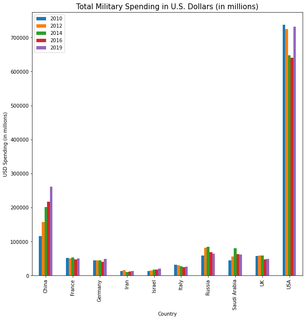

```python
# I decided to use a multi-bar graph because it allowed me to visualize each country per year
# This model also allows me to compare trends between countries

USD.plot(kind = 'bar', figsize = (10,10)) #setting kind of graph and size of figure
plt.title("Total Military Spending in U.S. Dollars (in millions)", fontsize=15) #Set title, font size
plt.xlabel("Country", fontsize=10) #set x-axis, font size
plt.ylabel("USD Spending (in millions)", fontsize=10) #set x-axis, font size
plt.show()
```

### 3.1.2- Graphing Overall Military Spending in Percent Values

```python
# In order to find the perent values of the 10 countries, I needed to find the value
# of the current military spending in US Dollars and divide that value by the total
# amount being spend every year.

# I first wanted to add all of the values of all my countries over the five
# years I chose to look at.

totalSpending = USD.sum()
totalSpending
```

```
2010   1172118.71
2012   1234620.79
2014   1225965.96
2016   1179178.44
2019   1327727.17
dtype: float64
```

```python
# Using .div function, I divided the current military spending in US Dollars by the total sum
# Then, I multiplied that value by 100 to get the percent value.

USD_percent = USD.div(totalSpending, axis=1)*100
USD_percent
```

| Country | 2010 | 2012 | 2014 | 2016 | 2019 |
| --- | --- | --- | --- | --- | --- |
| China | 9.87 | 12.75 | 16.38 | 18.35 | 19.66 |
| France | 4.44 | 4.07 | 4.33 | 4.02 | 3.77 |
| Germany | 3.83 | 3.60 | 3.61 | 3.37 | 3.71 |
| Iran | 1.16 | 1.34 | 0.81 | 1.04 | 0.95 |
| Israel | 1.18 | 1.18 | 1.45 | 1.48 | 1.54 |
| Italy | 2.73 | 2.41 | 2.26 | 2.12 | 2.02 |
| Russia | 5.01 | 6.60 | 6.91 | 5.87 | 4.90 |
| Saudi Arabia | 3.86 | 4.58 | 6.59 | 5.40 | 4.66 |
| UK | 4.96 | 4.74 | 4.83 | 4.08 | 3.66 |
| USA | 62.96 | 58.74 | 52.84 | 54.26 | 55.11 |

```python
# Double-check that all years add up to 100

USD_percent.sum()
```

```
2010   100.00
2012   100.00
2014   100.00
2016   100.00
2019   100.00
dtype: float64
```

```python
# Define a function to call pie charts to show the percent of spending per year.
# Defined function by the percent of spending per year
    # labels = the list of the USD_percent index
    # autopct = Allows to display the percent value (to the 2nd decimal point)
    # starting angle is at 90 degree
    # pctdistance = distance the percent value is listed
    # labeldistance = distance the label is located on the pie chart
    # explode = the distance each piece of the pie is taken out of the cirlce


def pie_chart(year):
    plt.pie(USD_percent[year],
            labels=list(USD_percent.index),
            autopct="%.2f%%",
            startangle=90,
            pctdistance=.8,
            labeldistance=1.1,
            explode=(0.2,0.1,0.2,0.1,0.2,0.1,0.2,0.1,0.2,0.1))
    plt.title("Overall military spending in " + str(year) + " (%)")
```

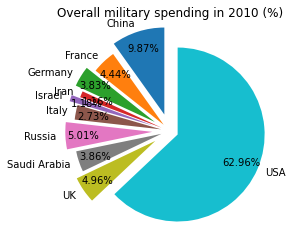

```python
pie_chart(2010)
```

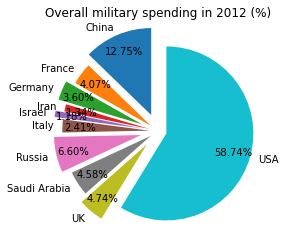

```python
pie_chart(2012)
```

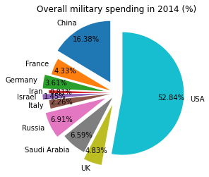

```python
pie_chart(2014)
```

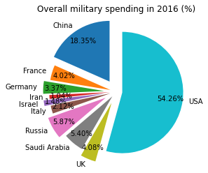

```python
pie_chart(2016)
```

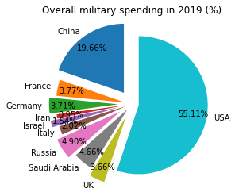

```python
pie_chart(2019)
```

### 3.1.3 -Graphing Overall Military Spending in Current USD

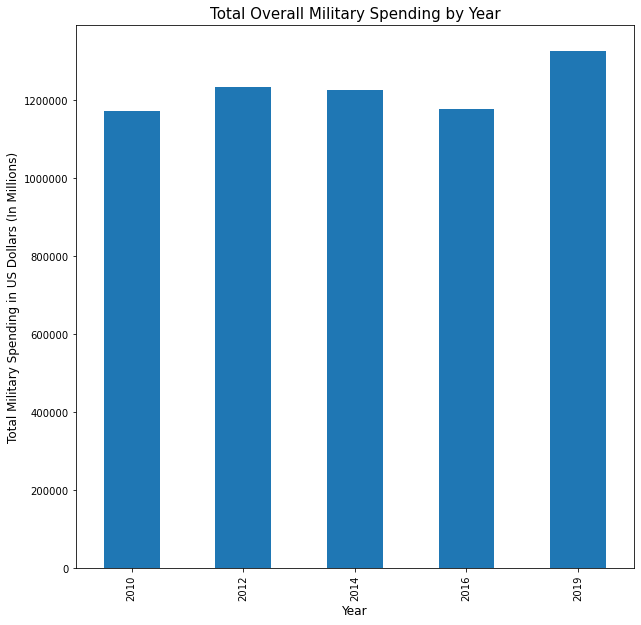

```python
# Graph shows combined total overal military spending by year by using a plot line graph

totalSpending.plot(figsize = (10,10), kind = 'bar')
plt.title ('Total Overall Military Spending by Year', fontsize = 15)
plt.xlabel('Year',fontsize = 12)
plt.ylabel('Total Military Spending in US Dollars (In Millions)', fontsize = 12)

# Getting rid of scientific notation value, allows for Current dollars to be shown
plt.gcf().axes[0].yaxis.get_major_formatter().set_scientific(False)

plt.show()
```

## 3.2 - Compare Military Spending to Country's GDP

### 3.2.1- Comparing Military Spending to Country's Overall GDP in Percent Values

```python
percentShareGDP # Calling to confirm values in graph
```

| Country | 2010 | 2012 | 2014 | 2016 | 2019 |
| --- | --- | --- | --- | --- | --- |
| China | 1.91 | 1.84 | 1.91 | 1.93 | 1.89 |
| France | 1.97 | 1.87 | 1.86 | 1.92 | 1.86 |
| Germany | 1.32 | 1.26 | 1.14 | 1.15 | 1.28 |
| Iran | 2.91 | 2.76 | 2.28 | 2.97 | 2.31 |
| Israel | 5.94 | 5.67 | 5.75 | 5.48 | 5.26 |
| Italy | 1.51 | 1.44 | 1.29 | 1.34 | 1.35 |
| Russia | 3.58 | 3.69 | 4.10 | 5.45 | 3.88 |
| Saudi Arabia | 8.57 | 7.68 | 10.68 | 9.87 | 7.98 |
| UK | 2.37 | 2.19 | 1.95 | 1.81 | 1.74 |
| USA | 4.92 | 4.48 | 3.70 | 3.42 | 3.41 |

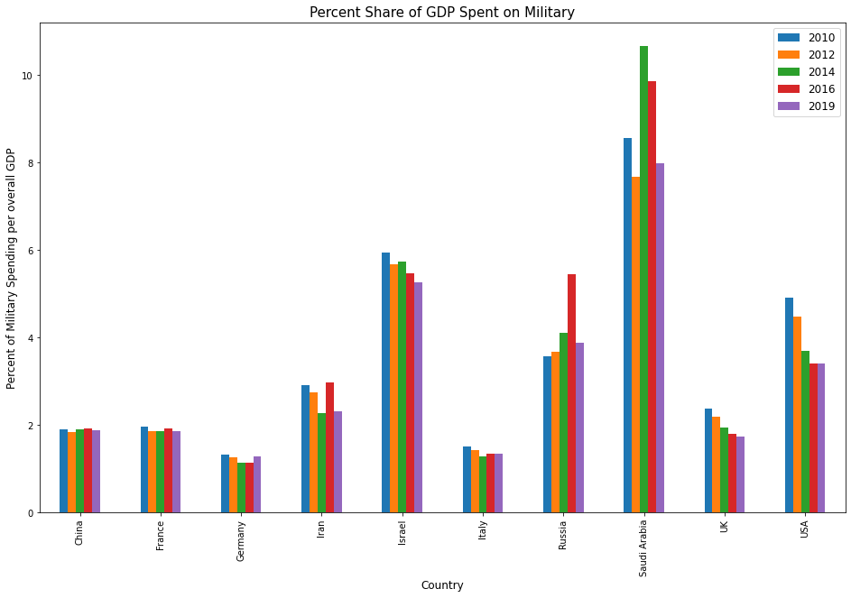

```python
# Plotting the shared GDP dataframe using a multibar plot

percentShareGDP.plot(figsize=(16,10), kind = 'bar')
plt.legend(bbox_to_anchor=(1, 1), fontsize=12)
plt.xlabel('Country', fontsize=12)
plt.ylabel('Percent of Military Spending per overall GDP', fontsize=12)
plt.title('Percent Share of GDP Spent on Military', fontsize=15)
plt.show()
```

```python
# stacks data in every countries for all years in Current US Spending in Millions dataframe
stackUSD = USD.stack()
stackUSD
```

```
Country
China         2010   115711.78
              2012   157390.38
              2014   200772.20
              2016   216404.28
              2019   261081.94
France        2010    52044.06
              2012    50216.51
              2014    53134.75
              2016    47370.59
              2019    50118.93
Germany       2010    44852.96
              2012    44470.34
              2014    44216.06
              2016    39724.91
```

[output cut: 37 more lines]

```python
# stacks data in every countries for total GDP spending
stackGDP = GDP.stack()
stackGDP
```

```
Country
China         2010    6066349.85
              2012    8570351.84
              2014   10534533.33
              2016   11212443.31
              2019   13824114.34
France        2010    2642609.38
              2012    2683823.85
              2014    2852165.90
              2016    2470715.34
              2019    2698599.42
Germany       2010    3396353.86
              2012    3527343.14
              2014    3883920.34
              2016    3465990.08
```

[output cut: 37 more lines]

### 3.2.2- Comparing Military Spending to Overall GDP in Absolute Values

```python
# combine the two stacked dataframe by concat function

USD_GDP = pd.concat([stackUSD,stackGDP], axis = 1) # axis = 1 because I'm looking for column, not index
USD_GDP.columns = ["Spending in USD", "Total GDP"]
USD_GDP
```

| Country |  | Spending in USD | Total GDP |
| --- | --- | --- | --- |
| China | 2010 | 115711.78 | 6066349.85 |
|  | 2012 | 157390.38 | 8570351.84 |
|  | 2014 | 200772.20 | 10534533.33 |
|  | 2016 | 216404.28 | 11212443.31 |
|  | 2019 | 261081.94 | 13824114.34 |
| France | 2010 | 52044.06 | 2642609.38 |
|  | 2012 | 50216.51 | 2683823.85 |
|  | 2014 | 53134.75 | 2852165.90 |
|  | 2016 | 47370.59 | 2470715.34 |
|  | 2019 | 50118.93 | 2698599.42 |
| Germany | 2010 | 44852.96 | 3396353.86 |
|  | 2012 | 44470.34 | 3527343.14 |
|  | 2014 | 44216.06 | 3883920.34 |
|  | 2016 | 39724.91 | 3465990.08 |
|  | 2019 | 49276.76 | 3851250.56 |
| Iran | 2010 | 13561.27 | 466518.07 |
|  | 2012 | 16493.96 | 598249.87 |
|  | 2014 | 9901.11 | 434053.64 |
|  | 2016 | 12263.96 | 412539.87 |
|  | 2019 | 12623.16 | 545956.55 |
| Israel | 2010 | 13875.21 | 233733.24 |
|  | 2012 | 14600.67 | 257435.13 |
|  | 2014 | 17810.04 | 310007.88 |
|  | 2016 | 17488.18 | 319256.74 |
|  | 2019 | 20464.93 | 389240.86 |
| Italy | 2010 | 32020.82 | 2125058.11 |
|  | 2012 | 29781.01 | 2072822.10 |
|  | 2014 | 27701.03 | 2151732.97 |
|  | 2016 | 25033.03 | 1868770.37 |
|  | 2019 | 26790.44 | 1982411.00 |
| Russia | 2010 | 58720.23 | 1638463.64 |
|  | 2012 | 81469.40 | 2210257.52 |
|  | 2014 | 84696.50 | 2063663.36 |
|  | 2016 | 69245.31 | 1269995.36 |
|  | 2019 | 65102.57 | 1678511.99 |
| Saudi Arabia | 2010 | 45244.53 | 528207.30 |
|  | 2012 | 56497.87 | 735974.84 |
|  | 2014 | 80762.40 | 756350.26 |
|  | 2016 | 63672.80 | 644935.56 |
|  | 2019 | 61866.67 | 775287.74 |
| UK | 2010 | 58082.85 | 2452900.97 |
|  | 2012 | 58495.66 | 2676605.37 |
|  | 2014 | 59182.86 | 3036876.34 |
|  | 2016 | 48118.94 | 2657359.76 |
|  | 2019 | 48650.38 | 2790452.11 |
| USA | 2010 | 738005 | 14992052.00 |
|  | 2012 | 725205 | 16197007.25 |
|  | 2014 | 647789 | 17527275.00 |
|  | 2016 | 639856.44 | 18715050.00 |
|  | 2019 | 731751.40 | 21439453.00 |

```python
# Creating new double bar chart based off of new concat df (USD_GDP) to compare total military spending and total GDP
# Defining a function in order to apply it to all of my countries per year

def bar(Country):
    USD_GDP_total = USD_GDP.loc[Country]  # calling the Country index

# Setting visualization for bar graph
    USD_GDP_total.plot(figsize=(5,5), kind = 'bar')
    plt.legend(bbox_to_anchor=(1, 1), fontsize=12)
    plt.title('Total Military Spending (US Dollars) vs. Total GDP Spending in ' + str(Country), fontsize=15)
    plt.xlabel('Year', fontsize=12)
    plt.ylabel('Spending in US Dollars (in millions)', fontsize=12)

# Getting rid of scientific notation value, allows for Current dollars to be shown
    plt.gcf().axes[0].yaxis.get_major_formatter().set_scientific(False)

    plt.show()
```

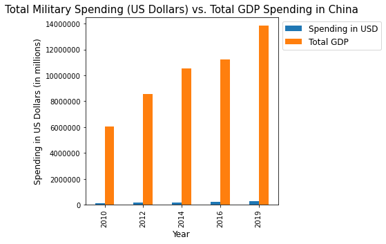

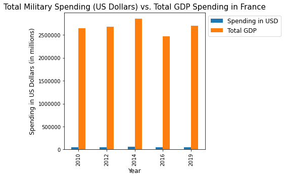

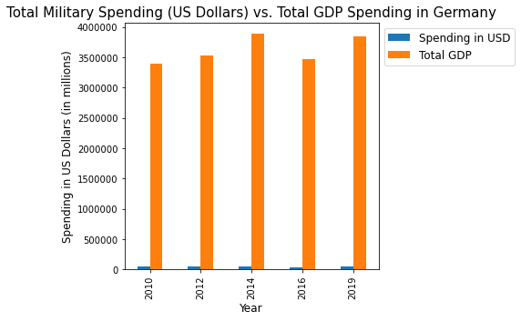

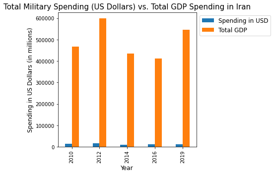

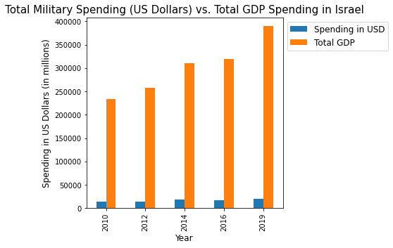

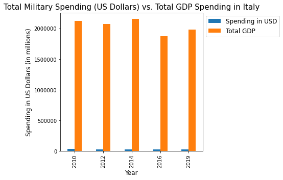

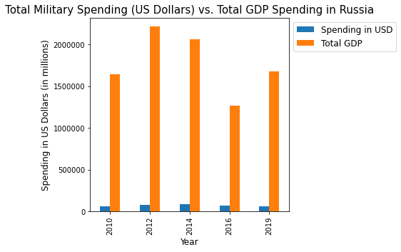

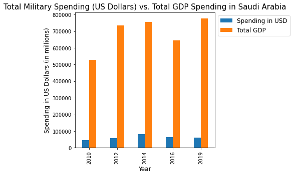

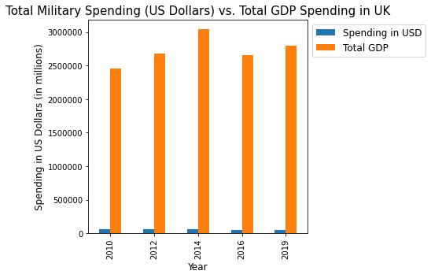

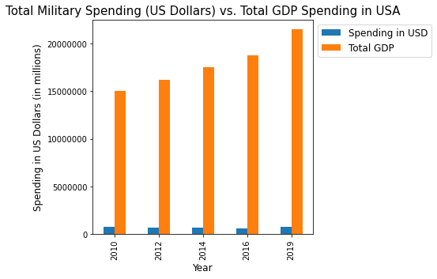

```python
# Calling out countries from defined function above to show double-bar graph between Spending in USD in Total GDP

bar('China')
bar('France')
bar('Germany')
bar('Iran') # Notice me!
bar('Israel') # Notice me!
bar('Italy')
bar('Russia') # Notice me!
bar('Saudi Arabia') # Notice me!
bar('UK')
bar('USA') # Notice me!
```

## 3.3 - Graphing Per Person Military Spending to Per Person GDP (in Absolute and Percent Values)

### 3.3.1- Graphing Per Person Military Spending to Per Person GDP in Absolute Values

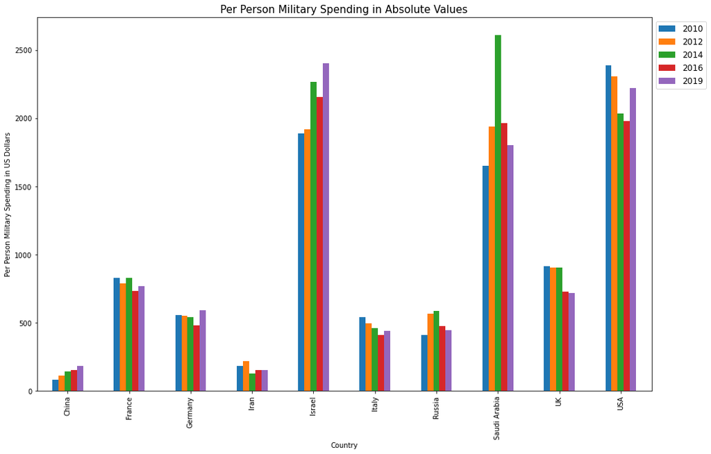

```python
# I calculated the absolute per person military spending by dividing the current spending in US Dollars/population
# value.

# Using this dataframe, I decided to create a multi-bar graph in order to compare the years within the country as well
# as the countries overall

pop.plot(figsize=(16,10), kind = 'bar')
plt.legend(bbox_to_anchor=(1, 1), fontsize=12)
plt.xlabel('Country')
plt.ylabel('Per Person Military Spending in US Dollars')
plt.title('Per Person Military Spending in Absolute Values', fontsize=15)
plt.show()
```

### 3.3.2- Graphing Per Person Military Spending to Per Person GDP in Percent Values

```python
percentPerPersonSpending # Call to confirm
```

| Country | 2010 | 2012 | 2014 | 2016 | 2019 |
| --- | --- | --- | --- | --- | --- |
| China | 1.91 | 1.84 | 1.91 | 1.93 | 1.89 |
| France | 1.97 | 1.87 | 1.86 | 1.92 | 1.86 |
| Germany | 1.32 | 1.26 | 1.14 | 1.15 | 1.28 |
| Iran | 2.91 | 2.76 | 2.28 | 2.97 | 2.31 |
| Israel | 5.94 | 5.67 | 5.75 | 5.48 | 5.26 |
| Italy | 1.51 | 1.44 | 1.29 | 1.34 | 1.35 |
| Russia | 3.58 | 3.69 | 4.10 | 5.45 | 3.88 |
| Saudi Arabia | 8.57 | 7.68 | 10.68 | 9.87 | 7.98 |
| UK | 2.37 | 2.19 | 1.95 | 1.81 | 1.74 |
| USA | 4.92 | 4.48 | 3.70 | 3.42 | 3.41 |

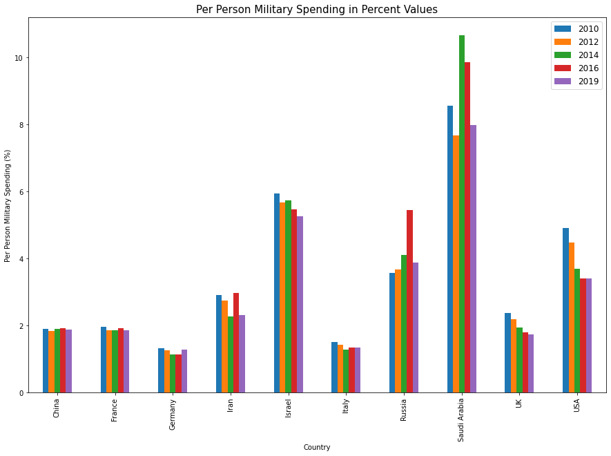

```python
# I calculated the percent per person military spending by dividing the per capita spending/per capita GDP.
# Using this dataframe, I decided to create a multi-bar graph in order to compare the years within the country as well
# as the countries overall.

percentPerPersonSpending.plot(figsize=(15,10), kind = 'bar')
plt.legend(bbox_to_anchor=(1, 1), fontsize=12)
plt.xlabel('Country')
plt.ylabel('Per Person Military Spending (%)')
plt.title('Per Person Military Spending in Percent Values', fontsize=15)
plt.show()
```

## 3.4 - Fastest growing countries

```python
# The 'Difference' is my absolute value of military spending growth in countries.
# To find this value, you need to subtract the earliest year from the 'current military spending
# value from the latest year'.

USD['Difference'] = USD[2019] - USD[2010]

# The 'Growth Rate Percent' shows the percentage at which each country is growing. To find this value,
# I took the differences df I created and divided it by the earliest year of current spending. Then, I multiplied
# this by 100 to convert the decimals to a percent value.

USD['Growth Rate Percent'] = (USD['Difference']/ USD[2010]) * 100
USD
```

| Country | 2010 | 2012 | 2014 | 2016 | 2019 | Difference | Growth Rate Percent |
| --- | --- | --- | --- | --- | --- | --- | --- |
| China | 115711.78 | 157390.38 | 200772.20 | 216404.28 | 261081.94 | 145370.16 | 125.63 |
| France | 52044.06 | 50216.51 | 53134.75 | 47370.59 | 50118.93 | -1925.13 | -3.70 |
| Germany | 44852.96 | 44470.34 | 44216.06 | 39724.91 | 49276.76 | 4423.80 | 9.86 |
| Iran | 13561.27 | 16493.96 | 9901.11 | 12263.96 | 12623.16 | -938.11 | -6.92 |
| Israel | 13875.21 | 14600.67 | 17810.04 | 17488.18 | 20464.93 | 6589.72 | 47.49 |
| Italy | 32020.82 | 29781.01 | 27701.03 | 25033.03 | 26790.44 | -5230.38 | -16.33 |
| Russia | 58720.23 | 81469.40 | 84696.50 | 69245.31 | 65102.57 | 6382.34 | 10.87 |
| Saudi Arabia | 45244.53 | 56497.87 | 80762.40 | 63672.80 | 61866.67 | 16622.13 | 36.74 |
| UK | 58082.85 | 58495.66 | 59182.86 | 48118.94 | 48650.38 | -9432.47 | -16.24 |
| USA | 738005 | 725205 | 647789 | 639856.44 | 731751.40 | -6253.60 | -0.85 |

### 3.4.1- Fastest growing countries in absolute values

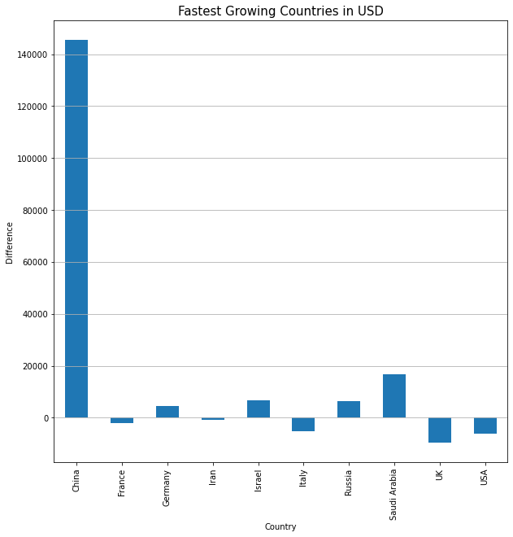

```python
# We use the -2 index because that is where the 'Difference' position in the current USD Database
# By graphing this chart as a bar graph, I plotted the fastest growing countries graph as a bar graph.

#iloc = 'Difference' column is at -2 index of df
USD.iloc[:,-2].plot.bar(figsize = (10,10))
plt.title('Fastest Growing Countries in USD', fontsize=15)
plt.xlabel('Country')
plt.ylabel('Difference')

# This brings out the grid on the y axis, helps show whether or not the values are above or below zero
plt.grid(axis='y')
plt.show()
```

### 3.4.2 - Fastest growing countries in percent values

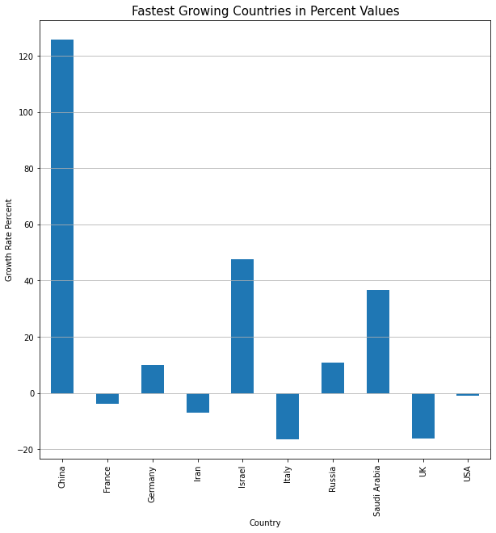

```python
# Vistualization of the fastest growing countries in percentage
# By graphing this chart as a bar graph, I plotted the fastest growing countries graph as a bar graph.

# iloc = 'Growth Rate Percent' column is at -1 index of df
USD.iloc[:,-1].plot.bar(figsize = (10,10))
plt.title('Fastest Growing Countries in Percent Values', fontsize=15)
plt.xlabel('Country')
plt.ylabel('Growth Rate Percent')

# This brings out the grid on the y axis, helps show whether or not the values are above or below zero
plt.grid(axis='y')
plt.show()
```

# Part 4 - Future Predictions

2020 has brought on the novel challenge that has effected countries globally: SARS-CoV-2 - better known as COVID-19. According to the World Health Organization (https://covid19.who.int/), over one million people have died from this disease as of October 2020. Moreover, over 37 million individuals have been confirmed with having been infected with this virus. Each country has dealt with this novel disease drastically differently. I anticipate that 2020's GDP trends will change drastically globally.

In this prediction, I decided not to include Russia and China because there was no available data for them.

```python
# I used the exact same model as I did above to show total military spending per country and year as I did above
# (both in absolute and percent values).

# All dataframes in this section will be denoted with '_flu'.

xls = pd.ExcelFile('Military_spending.xlsx')
USD_flu = xls.parse('Current USD')
USD_flu = pd.read_excel(xls, 'Current USD', skiprows=5, index_col=0)
USD_flu.replace(("xxx",". ."), "N/A", inplace=True)
USD_flu.fillna("N/A", inplace=True)
USD_flu.head()
```

| Country | Notes | 1949 | 1950 | 1951 | 1952 | 1953 | 1954 | 1955 | 1956 | 1957 | ... | 2010 | 2011 | 2012 | 2013 | 2014 | 2015 | 2016 | 2017 | 2018 | 2019 |
| --- | --- | --- | --- | --- | --- | --- | --- | --- | --- | --- | --- | --- | --- | --- | --- | --- | --- | --- | --- | --- | --- |
| Africa | N/A | N/A | N/A | N/A | N/A | N/A | N/A | N/A | N/A | N/A | ... | N/A | N/A | N/A | N/A | N/A | N/A | N/A | N/A | N/A | N/A |
| North Africa | N/A | N/A | N/A | N/A | N/A | N/A | N/A | N/A | N/A | N/A | ... | N/A | N/A | N/A | N/A | N/A | N/A | N/A | N/A | N/A | N/A |
| Algeria | 1 | N/A | N/A | N/A | N/A | N/A | N/A | N/A | N/A | N/A | ... | 5671.31 | 8652.24 | 9326.29 | 10161.59 | 9724.38 | 10412.71 | 10217.08 | 10073.36 | 9583.72 | 10303.60 |
| Libya | ‡ ¶ 2 | N/A | N/A | N/A | N/A | N/A | N/A | N/A | N/A | N/A | ... | N/A | N/A | 2987.41 | 3964.69 | 3755.66 | N/A | N/A | N/A | N/A | N/A |
| Morocco | 3 | N/A | N/A | N/A | N/A | N/A | N/A | N/A | 23.71 | 35.40 | ... | 3160.80 | 3342.70 | 3402.70 | 4065.55 | 4048.61 | 3268.36 | 3327.03 | 3461.46 | 3696.86 | 3721.32 |

5 rows × 72 columns

```python
# Defining a new function 'fluChart' in order to create a new dataframe.

def fluChart(xls):
    rname = ['USA', 'Germany', 'UK', 'France', 'Italy', 'Iran', 'Israel',
             'Saudi Arabia']
    cname = [1967, 1968, 1969, 1970, 1971]

    xls = xls.loc[rname, cname]
    return xls
```

```python
USD_flu = fluChart(USD_flu).sort_values("Country")
USD_flu
```

| Country | 1967 | 1968 | 1969 | 1970 | 1971 |
| --- | --- | --- | --- | --- | --- |
| France | 4918.99 | 5149.00 | 4964.01 | 4941.06 | 5291.99 |
| Germany | 5119.19 | 4617.38 | 5233.57 | 5898.86 | 6940.11 |
| Iran | 331.02 | 437.29 | 566.01 | 620.13 | 402.31 |
| Israel | 605.51 | 690.00 | 872.00 | 1259.65 | 1270.66 |
| Italy | 1928.79 | 1991.17 | 2003.81 | 2216.77 | 2648.08 |
| Saudi Arabia | 336.22 | 338.67 | 429.33 | 471.56 | 587.27 |
| UK | 6200.58 | 5563.20 | 5544.60 | 6074.40 | 6723.94 |
| USA | 78398.44 | 84329.03 | 84990.17 | 83407.99 | 78237.98 |

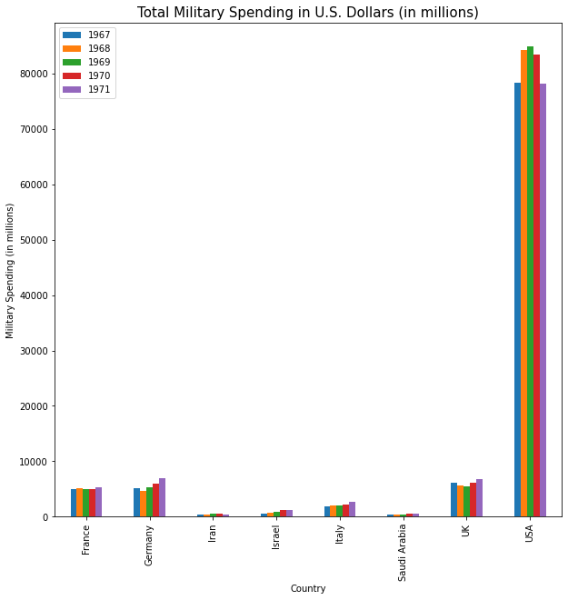

```python
USD_flu.plot(kind = 'bar', figsize = (10,10))
plt.title("Total Military Spending in U.S. Dollars (in millions)", fontsize=15)
plt.xlabel("Country", fontsize=10)
plt.ylabel("Military Spending (in millions)", fontsize=10)
plt.show()
```

```python
xls = pd.ExcelFile('Military_spending.xlsx')
shareGDP_flu = xls.parse('Share of GDP')
shareGDP_flu = pd.read_excel(xls, 'Share of GDP', skiprows=5, index_col=0)
shareGDP_flu.replace(("xxx",". ."), "N/A", inplace=True)
shareGDP_flu.fillna("N/A", inplace=True)
shareGDP_flu.head()
```

| Country | Notes | 1949 | 1950 | 1951 | 1952 | 1953 | 1954 | 1955 | 1956 | 1957 | ... | 2010 | 2011 | 2012 | 2013 | 2014 | 2015 | 2016 | 2017 | 2018 | 2019 |
| --- | --- | --- | --- | --- | --- | --- | --- | --- | --- | --- | --- | --- | --- | --- | --- | --- | --- | --- | --- | --- | --- |
| Africa | N/A | N/A | N/A | N/A | N/A | N/A | N/A | N/A | N/A | N/A | ... | N/A | N/A | N/A | N/A | N/A | N/A | N/A | N/A | N/A | N/A |
| North Africa | N/A | N/A | N/A | N/A | N/A | N/A | N/A | N/A | N/A | N/A | ... | N/A | N/A | N/A | N/A | N/A | N/A | N/A | N/A | N/A | N/A |
| Algeria | 1 | N/A | N/A | N/A | N/A | N/A | N/A | N/A | N/A | N/A | ... | 0.04 | 0.04 | 0.04 | 0.05 | 0.06 | 0.06 | 0.06 | 0.06 | 0.06 | 0.06 |
| Libya | ‡ ¶ 2 | N/A | N/A | N/A | N/A | N/A | N/A | N/A | N/A | N/A | ... | N/A | N/A | 0.04 | 0.08 | 0.15 | N/A | N/A | N/A | N/A | N/A |
| Morocco | 3 | N/A | N/A | N/A | N/A | N/A | N/A | N/A | 0.01 | 0.02 | ... | 0.03 | 0.03 | 0.03 | 0.04 | 0.04 | 0.03 | 0.03 | 0.03 | 0.03 | 0.03 |

5 rows × 72 columns

```python
shareGDP_flu = fluChart(shareGDP_flu).sort_values("Country")
percentShareGDP_flu = shareGDP_flu*100
percentShareGDP_flu
```

| Country | 1967 | 1968 | 1969 | 1970 | 1971 |
| --- | --- | --- | --- | --- | --- |
| France | 4.30 | 4.14 | 3.68 | 3.46 | 3.32 |
| Germany | 4.14 | 3.46 | 3.45 | 3.06 | 3.11 |
| Iran | 4.46 | 5.18 | 5.97 | 5.86 | 3.05 |
| Israel | 15.44 | 17.43 | 19.09 | 23.45 | 22.80 |
| Italy | 2.77 | 2.65 | 2.42 | 2.06 | 2.24 |
| Saudi Arabia | 11.51 | 8.09 | 9.57 | 9.40 | 8.64 |
| UK | 5.58 | 5.31 | 4.92 | 4.65 | 4.54 |
| USA | 9.42 | 9.27 | 8.63 | 8.03 | 6.94 |

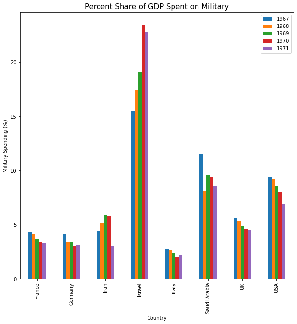

```python
percentShareGDP_flu.plot(kind = 'bar', figsize = (10,10))
plt.title("Percent Share of GDP Spent on Military", fontsize=15)
plt.xlabel("Country", fontsize=10)
plt.ylabel("Military Spending (%)", fontsize=10)
plt.show()
```

This prediction is limited in many ways. First, the current political climate is not going to be exactly the same in each country. Second, the 1968-1969 influenza strand did not have the same global effect as COVID-19. Third, it would be difficult to confirm whether any changes in spending was directly correlated with this disease. Last, government powers in each country view the differently now than they did back in the late 1960's.

However, I do believe that there is an opportunity for further research in order to see what, if any coorelations, there are with major global events and their effects on GDP spending.